# Iskander et al, Science Translational Medicine, 2021

Guanlin Wang

##### Figure 4. Glucocorticoid pathway-deficient stress erythropoiesis and ZFP36L2-mediated erythroid differentiation inhibition by glucocorticoids are observed in DBA.

##### load the library and object

```r
library(SingCellaR)
library(ggplot2)
library(gridExtra)
library(ggpubr)
source("/Users/gwang/DBA/DBA_revision/Scripts/plot_violin_for_genes_per_custom_group_of_cell.R")
load(file = "/Users/gwang/DBA/DBA_revision/DBA_MKE.merged.louvain.rdata")
```

##### A) Violin plots depicting the mean expression (yellow dot) and distribution (minimum to maximum) of HBG2, a stress erythropoiesis gene in control, RPS-DBA and RPL-DBA EP subclusters (EEP, Ecycling and LEP). The fraction of cells expressing HBG2 is shown on the x axis.

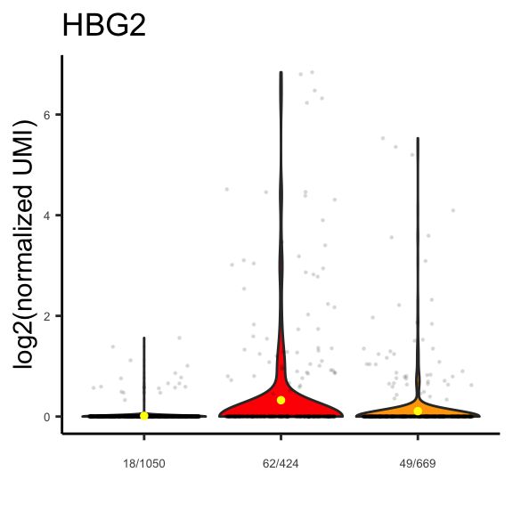

```r
umap.results <- DBA_MKE@umap.result
sc.clusters <- DBA_MKE@sc.clusters

EEP <- sc.clusters[sc.clusters$merged_louvain == "cl1",]
LEP <- sc.clusters[sc.clusters$merged_louvain == "cl3",]
Ecyc <- sc.clusters[sc.clusters$merged_louvain == "cl4",]

WT.cells <- umap.results$Cell[umap.results$genotype == "WT"]
RPS.cells <- umap.results$Cell[umap.results$genotype == "RPS"]
RPL.cells <- umap.results$Cell[umap.results$genotype == "RPL"]

EEP.WT <- EEP$Cell[EEP$Cell %in% WT.cells]
EEP.RPS <- EEP$Cell[EEP$Cell %in% RPS.cells]
EEP.RPL <- EEP$Cell[EEP$Cell %in% RPL.cells]

LEP.WT <- LEP$Cell[LEP$Cell %in% WT.cells]
LEP.RPS <- LEP$Cell[LEP$Cell %in% RPS.cells]
LEP.RPL <- LEP$Cell[LEP$Cell %in% RPL.cells]

Ecyc.WT <- Ecyc$Cell[Ecyc$Cell %in% WT.cells]
Ecyc.RPS <- Ecyc$Cell[Ecyc$Cell %in% RPS.cells]
Ecyc.RPL <- Ecyc$Cell[Ecyc$Cell %in% RPL.cells]


plot_violin_for_genes_per_custom_group_of_cells(DBA_MKE,
                                                custom_group_of_cells = list(EEP.WT,EEP.RPS,EEP.RPL),
                                                gene_list = "HBG2",
                                                take_log2 = T
)
```

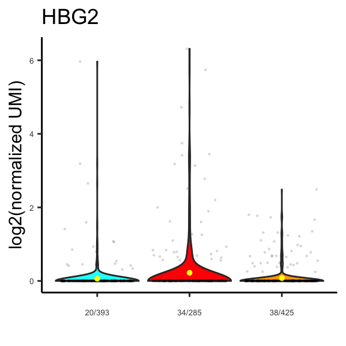

```r
plot_violin_for_genes_per_custom_group_of_cells(DBA_MKE,
                                                custom_group_of_cells = list(Ecyc.WT,Ecyc.RPS,Ecyc.RPL),
                                                gene_list = "HBG2",
                                                take_log2 = T
)
```

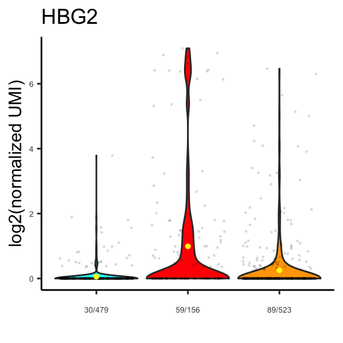

```r
plot_violin_for_genes_per_custom_group_of_cells(DBA_MKE,
                                                custom_group_of_cells = list(LEP.WT,LEP.RPS,LEP.RPL),
                                                gene_list = "HBG2",
                                                take_log2 = T
)
```

##### B) Mean expression (yellow dot) and distribution of AUCell score of stress erythropoiesis (SE) gene set is shown for control, RPS-DBA and RPL-DBA EP subclusters.

##### D) The AUCell score of glucocorticoid response genes in control, RPS-DBA and RPL-DBA EP subclusters is shown by violin plots.

```r
# this steps takes large memory and long time to run

# Build_AUCell_Rankings(DBA_MKE,AUCell_buildRankings.file = "/Users/gwang/DBA/DBA_revision/Objects/DBA_MKE.AUcell.rankings",nCores = 8,plotStats = T)
# DBA_MKE.AUcell.rankings <- Run_AUCell(DBA_MKE,AUCell_buildRankings.file = "/Users/gwang/DBA/DBA_revision/Objects/DBA_MKE.AUcell.rankings",geneSets.gmt.file = "/Users/gwang/DBA/DBA_revision/Scripts/Generating object/SE_GC.gmt",n.random.genes =500)
# save(DBA_MKE.AUcell.rankings,file = "/Users/gwang/DBA/DBA_revision/Objects/DBA_MKE.AUcell.rdata")

# here we used the AUcell score directly
load(file = "/Users/gwang/DBA/DBA_revision/Objects/DBA_MKE.AUcell.rdata")


umap.results <- DBA_MKE@umap.result
sc.clusters <- DBA_MKE@sc.clusters

EEP <- sc.clusters[sc.clusters$merged_louvain == "cl1",]
LEP <- sc.clusters[sc.clusters$merged_louvain == "cl3",]
Ecyc <- sc.clusters[sc.clusters$merged_louvain == "cl4",]

WT.cells <- umap.results$Cell[umap.results$genotype == "WT"]
RPS.cells <- umap.results$Cell[umap.results$genotype == "RPS"]
RPL.cells <- umap.results$Cell[umap.results$genotype == "RPL"]

EEP.WT <- EEP$Cell[EEP$Cell %in% WT.cells]
EEP.RPS <- EEP$Cell[EEP$Cell %in% RPS.cells]
EEP.RPL <- EEP$Cell[EEP$Cell %in% RPL.cells]

LEP.WT <- LEP$Cell[LEP$Cell %in% WT.cells]
LEP.RPS <- LEP$Cell[LEP$Cell %in% RPS.cells]
LEP.RPL <- LEP$Cell[LEP$Cell %in% RPL.cells]

Ecyc.WT <- Ecyc$Cell[Ecyc$Cell %in% WT.cells]
Ecyc.RPS <- Ecyc$Cell[Ecyc$Cell %in% RPS.cells]
Ecyc.RPL <- Ecyc$Cell[Ecyc$Cell %in% RPL.cells]


DBA_MKE.AUcell.rankings$group[rownames(DBA_MKE.AUcell.rankings) %in% EEP.WT] <- "EEP_WT"
DBA_MKE.AUcell.rankings$group[rownames(DBA_MKE.AUcell.rankings) %in% EEP.RPS] <- "EEP_RPS"
DBA_MKE.AUcell.rankings$group[rownames(DBA_MKE.AUcell.rankings) %in% EEP.RPL] <- "EEP_RPL"
DBA_MKE.AUcell.rankings$group[rownames(DBA_MKE.AUcell.rankings) %in% LEP.WT] <- "LEP_WT"
DBA_MKE.AUcell.rankings$group[rownames(DBA_MKE.AUcell.rankings) %in% LEP.RPS] <- "LEP_RPS"
DBA_MKE.AUcell.rankings$group[rownames(DBA_MKE.AUcell.rankings) %in% LEP.RPL] <- "LEP_RPL"
DBA_MKE.AUcell.rankings$group[rownames(DBA_MKE.AUcell.rankings) %in% Ecyc.WT] <- "Ecyc_WT"
DBA_MKE.AUcell.rankings$group[rownames(DBA_MKE.AUcell.rankings) %in% Ecyc.RPS] <- "Ecyc_RPS"
DBA_MKE.AUcell.rankings$group[rownames(DBA_MKE.AUcell.rankings) %in% Ecyc.RPL] <- "Ecyc_RPL"


head(DBA_MKE.AUcell.rankings)
```

```
##                         Stress_genes  GC_genes random_gene    group
## AAACCCAAGTATGAAC-1_BP04   0.03538492 0.2873149  0.05211539  EEP_RPL
## AAACGAACAATGTCTG-1_BP04   0.04537898 0.3793517  0.05263764  EEP_RPL
## AAACGAACACACCGAC-1_BP04   0.03766739 0.2771394  0.05051314 Ecyc_RPL
## AAACGAAGTCGTGTTA-1_BP04   0.04369681 0.3377923  0.04827213  EEP_RPL
## AAACGAATCAAGCCCG-1_BP04   0.04534600 0.3347339  0.05126421 Ecyc_RPL
## AAACGCTGTGCCTATA-1_BP04   0.03452075 0.3365346  0.04909961  EEP_RPL
```

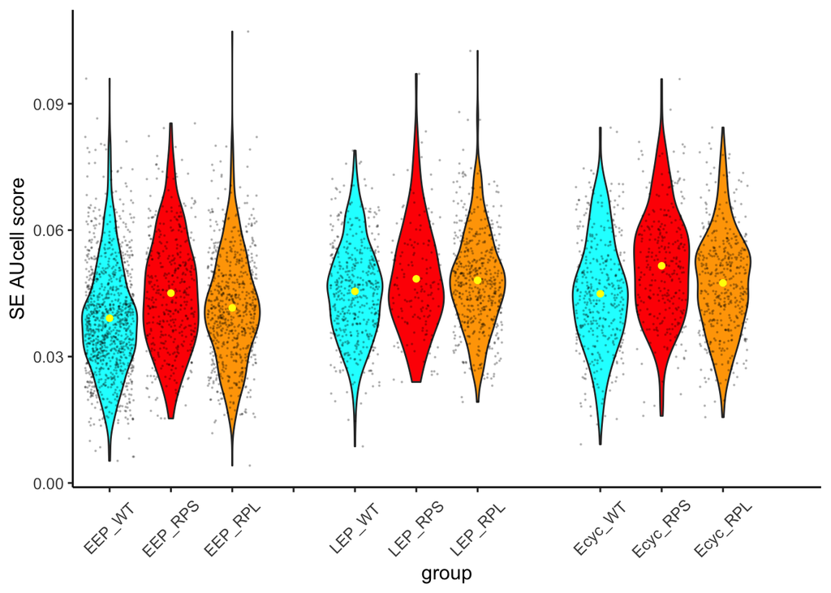

```r
ggplot(data = DBA_MKE.AUcell.rankings,aes(x = group, y = Stress_genes,fill = group)) +
  geom_violin(trim=TRUE,scale="width") +
  geom_jitter(height = 0,size=0.1,alpha = 0.2) +
  stat_summary(fun.y = mean, geom = "point", color = "yellow") +
  scale_fill_manual(values= c("orange", "red", "cyan","orange", "red", "cyan","orange", "red", "cyan")) +
  scale_x_discrete(limits = c("EEP_WT","EEP_RPS","EEP_RPL","",
                              "LEP_WT","LEP_RPS","LEP_RPL","",
                              "Ecyc_WT","Ecyc_RPS","Ecyc_RPL","")) +
  theme_classic2() +
  theme(axis.text.x = element_text(angle = 45,vjust = 0.5,hjust = 0.5)) +
  theme(legend.position="none") +
  xlab("group") +
  ylab("SE AUcell score")
```

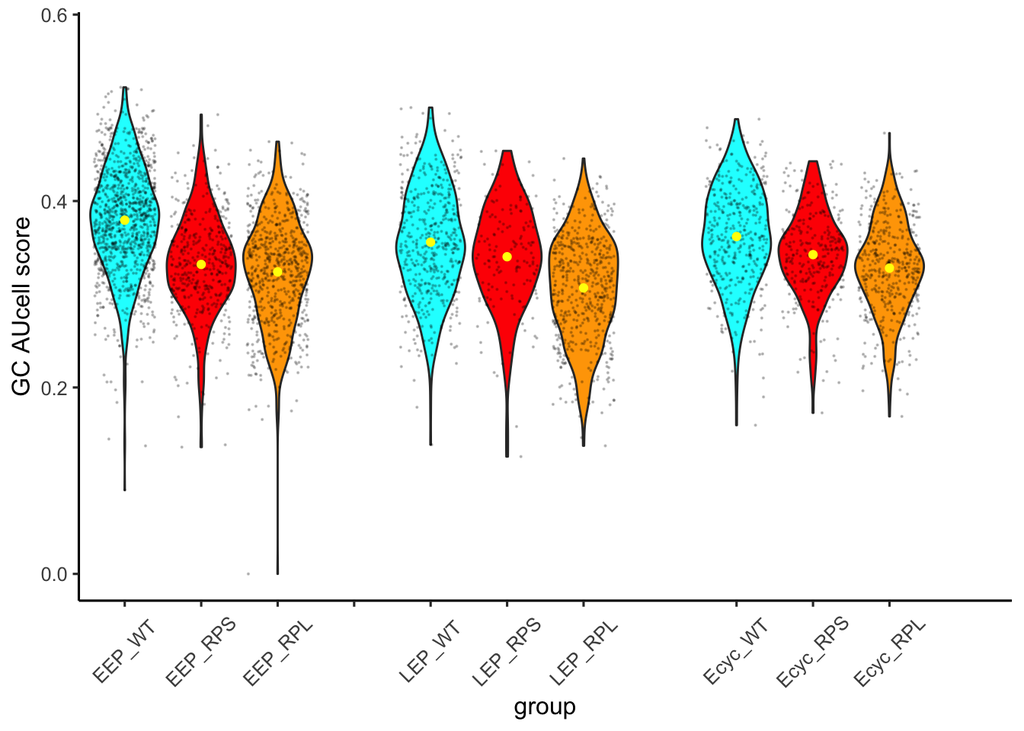

```r
ggplot(data = DBA_MKE.AUcell.rankings,aes(x = group, y = GC_genes,fill = group)) +
  geom_violin(trim=TRUE,scale="width") +
  geom_jitter(height = 0,size=0.1,alpha = 0.2) +
  stat_summary(fun.y = mean, geom = "point", color = "yellow") +
  scale_fill_manual(values= c("orange", "red", "cyan","orange", "red", "cyan","orange", "red", "cyan")) +
  scale_x_discrete(limits = c("EEP_WT","EEP_RPS","EEP_RPL","",
                              "LEP_WT","LEP_RPS","LEP_RPL","",
                              "Ecyc_WT","Ecyc_RPS","Ecyc_RPL","")) +
  theme_classic2() +
  theme(axis.text.x = element_text(angle = 45,vjust = 0.5,hjust = 0.5)) +
  theme(legend.position="none") +
  xlab("group") +
  ylab("GC AUcell score")
```

##### C) A bubble plot shows the expression of erythroid differentiation genes in control, RPS-DBA and RPL-DBA EP subclusters.

```r
gene.list <- rev(c("HBB","HBA2","HBA1","AHSP"))
gene.list
```

```
## [1] "AHSP" "HBA1" "HBA2" "HBB"
```

```r
normalized.umi <- get_normalized_umi(DBA_MKE)
cells <- DBA_MKE@umap.result$Cell
normalized.umi <- normalized.umi[gene.list,cells]

umap.results <- DBA_MKE@umap.result
sc.clusters <- DBA_MKE@sc.clusters
umap.results <- umap.results[match(sc.clusters$Cell,umap.results$Cell),]
identical(as.character(umap.results$Cell),as.character(sc.clusters$Cell))
```

```
## [1] TRUE
```

```r
sc.clusters$genotype <- umap.results$genotype
sc.clusters$type <- paste(sc.clusters$genotype,sc.clusters$merged_louvain,sep = "_")
sc.clusters$subset <- as.numeric(factor(sc.clusters$type))


data <- data.frame()
for (i in 1:length(gene.list)){
  gene <- as.character(gene.list[i])
  expr <- normalized.umi[gene,]
  for (j in 1:12){
    cluster.id = j
    cells <- sc.clusters$Cell[sc.clusters$subset == cluster.id]
    used.expr <- expr[names(expr) %in% cells]
    used.expr <- as.numeric(used.expr)
    n.exp <- length(used.expr[used.expr>0])
    expr.fract <- round(n.exp/length(used.expr) *100)
    expr.mean <- mean(used.expr)
    expr.mean <- log2(expr.mean +1)
    mat <- data.frame(gene =gene,subset = cluster.id, percent = expr.fract, expression = expr.mean)
    data <- rbind(data,mat)

  }

}
# data


sc.clusters.used <- sc.clusters[,c("merged_louvain","subset","genotype","type")]
sc.clusters.used <- sc.clusters[!duplicated(sc.clusters.used$type),]
sc.clusters.used
```

```
##                           Cell louvain_cluster louvain_cluster_color
## 1      AAACCCAAGTATGAAC-1_BP04             cl1               #F8766D
## 3      AAACGAACACACCGAC-1_BP04             cl6               #00B9E3
## 7      AAAGGATTCGAAGTGG-1_BP04             cl4               #00BA38
## 13     AACAAAGAGGAAAGGT-1_BP04             cl5               #00C19F
## 2103 AAACCTGCAAGCTGAG-1_DBA1_2             cl3               #93AA00
## 2106 AACCGCGAGACTACAA-1_DBA1_2             cl6               #00B9E3
## 2107 AACGTTGTCCGCTGTT-1_DBA1_2             cl2               #D39200
## 2113 AAGGTTCGTTCGTGAT-1_DBA1_2             cl4               #00BA38
## 3511   AAACGAAAGCTACTAC-1_BP03             cl8               #DB72FB
## 3512   AAACGAACATAGACTC-1_BP03             cl6               #00B9E3
## 3514   AAACGCTAGACCAGCA-1_BP03             cl2               #D39200
## 3515   AAAGAACCAGAGTAAT-1_BP03             cl5               #00C19F
##      merged_louvain merged_louvain_color genotype    type subset
## 1               cl1              #F8766D      RPL RPL_cl1      1
## 3               cl4              #C77CFF      RPL RPL_cl4      4
## 7               cl3              #00BFC4      RPL RPL_cl3      3
## 13              cl2              #7CAE00      RPL RPL_cl2      2
## 2103            cl2              #7CAE00      RPS RPS_cl2      6
## 2106            cl4              #C77CFF      RPS RPS_cl4      8
## 2107            cl1              #F8766D      RPS RPS_cl1      5
## 2113            cl3              #00BFC4      RPS RPS_cl3      7
## 3511            cl3              #00BFC4       WT  WT_cl3     11
## 3512            cl4              #C77CFF       WT  WT_cl4     12
## 3514            cl1              #F8766D       WT  WT_cl1      9
## 3515            cl2              #7CAE00       WT  WT_cl2     10
```

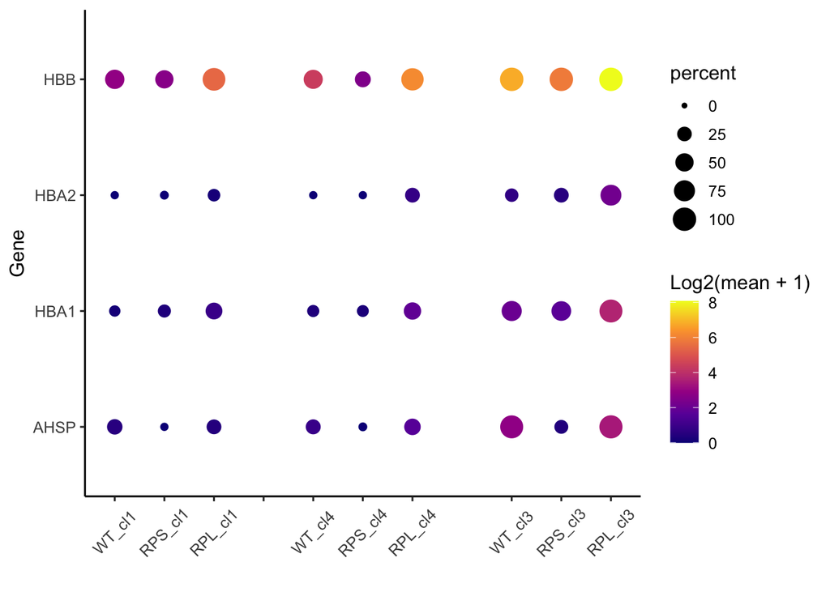

```r
sc.clusters.merged <- merge(data,sc.clusters.used, by.x = "subset",all.x = TRUE)
# sc.clusters.merged


ggplot(sc.clusters.merged,aes(x = type, y = gene, color = expression, size = percent)) +
  geom_point() +
  scale_color_viridis_c(name = 'Log2(mean + 1)',option = "C") +
  scale_x_discrete(limits = c("WT_cl1","RPS_cl1","RPL_cl1","",
                              "WT_cl4","RPS_cl4","RPL_cl4","",
                              "WT_cl3","RPS_cl3","RPL_cl3")) +
  theme_classic2() +
  theme(axis.text.x = element_text(angle = 45,vjust = 0.5,hjust = 0.5)) +
  xlab("") +
  ylab("Gene")
```

##### E) E) Violin plots depict the expression of ZFP36L2 in control, RPS-DBA and RPL-DBA EP subclusters. The fraction of cells expressing ZFP36L2 is shown on the x axis.

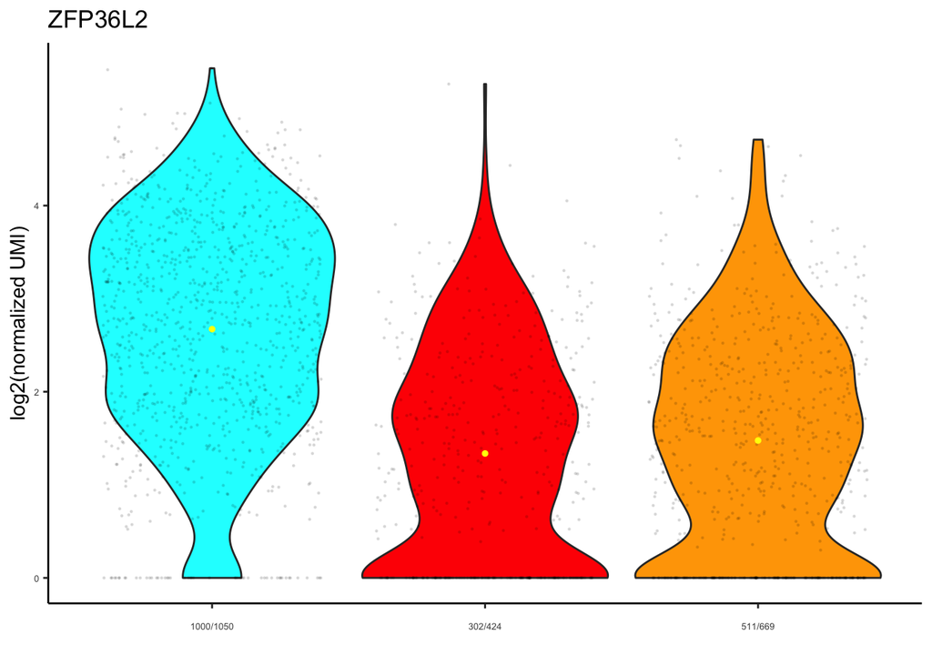

```r
plot_violin_for_genes_per_custom_group_of_cells<-function(object,custom_group_of_cells=list(),gene_list=c(),
                                                          take_log2=T,xlab.text.size=5,point.size=0.2,point.alpha=0.1,
                                                          grid.ncol = 1,grid.nrow=1){

  if(!is(object,"SingCellaR")){
    stop("Need to initialize the SingCellaR object")
  }
  if(length(gene_list)==0){
    stop("Required list of genes!")
  }

  ####################################
  umi.dat<-get_normalized_umi(object)
  my.p<-list()
  for(i in 1:length(gene_list)){
    my.gene<-as.character(gene_list)[i]
    my.sub.dat<-umi.dat[rownames(umi.dat)==my.gene,]
    my.new.dat<-data.frame()
    for(k in 1:length(custom_group_of_cells)){
      x.cell.names<-custom_group_of_cells[[k]]
      x.expr<-my.sub.dat[names(my.sub.dat) %in% as.character(x.cell.names)]
      ##################
      exp.val<-as.numeric(x.expr)
      n.exp<-length(exp.val[exp.val>0])
      n.total<-length(exp.val)
      my.label<-paste(names(custom_group_of_cells)[k],"\n",n.exp,"/",n.total,sep="")
      ##################
      y.legend<-""
      ##################
      if(take_log2==T){
        my.f<-data.frame(cluster=my.label,normUMI=log2(as.numeric(x.expr)+1))
        y.legend<-"log2(normalized UMI)"
      }else{
        my.f<-data.frame(cluster=my.label,normUMI=as.numeric(x.expr))
        y.legend<-"normalized UMI"
      }
      my.new.dat<-rbind(my.new.dat,my.f)
    }
    my.p[[i]]<-ggplot(
      data = my.new.dat,aes(x=cluster, y=normUMI,fill=cluster))+labs(y=y.legend)+
      geom_violin(trim=TRUE,scale="width")+
      geom_jitter(height = 0,size=point.size,alpha = point.alpha)+
      ggtitle(my.gene)+
      guides(fill=FALSE)+
      xlab("") +
      scale_fill_manual(values = c("cyan","red","orange")) +
      stat_summary(fun.y=mean, geom="point", size=1, color="yellow") +
      theme(axis.text=element_text(size=xlab.text.size))+
      theme(panel.grid.major = element_blank(), panel.grid.minor = element_blank(),panel.background = element_blank(), axis.line = element_line(colour = "black"))
  }
  grid.arrange(grobs = my.p,nrow=grid.nrow,ncol=grid.ncol)
}



umap.results <- DBA_MKE@umap.result
sc.clusters <- DBA_MKE@sc.clusters

EEP <- sc.clusters[sc.clusters$merged_louvain == "cl1",]
LEP <- sc.clusters[sc.clusters$merged_louvain == "cl3",]
Ecyc <- sc.clusters[sc.clusters$merged_louvain == "cl4",]

WT.cells <- umap.results$Cell[umap.results$genotype == "WT"]
RPS.cells <- umap.results$Cell[umap.results$genotype == "RPS"]
RPL.cells <- umap.results$Cell[umap.results$genotype == "RPL"]

EEP.WT <- EEP$Cell[EEP$Cell %in% WT.cells]
EEP.RPS <- EEP$Cell[EEP$Cell %in% RPS.cells]
EEP.RPL <- EEP$Cell[EEP$Cell %in% RPL.cells]

LEP.WT <- LEP$Cell[LEP$Cell %in% WT.cells]
LEP.RPS <- LEP$Cell[LEP$Cell %in% RPS.cells]
LEP.RPL <- LEP$Cell[LEP$Cell %in% RPL.cells]

Ecyc.WT <- Ecyc$Cell[Ecyc$Cell %in% WT.cells]
Ecyc.RPS <- Ecyc$Cell[Ecyc$Cell %in% RPS.cells]
Ecyc.RPL <- Ecyc$Cell[Ecyc$Cell %in% RPL.cells]


plot_violin_for_genes_per_custom_group_of_cells(DBA_MKE,
                                                custom_group_of_cells = list(EEP.WT,EEP.RPS,EEP.RPL),
                                                gene_list = "ZFP36L2",
                                                take_log2 = T
)
```

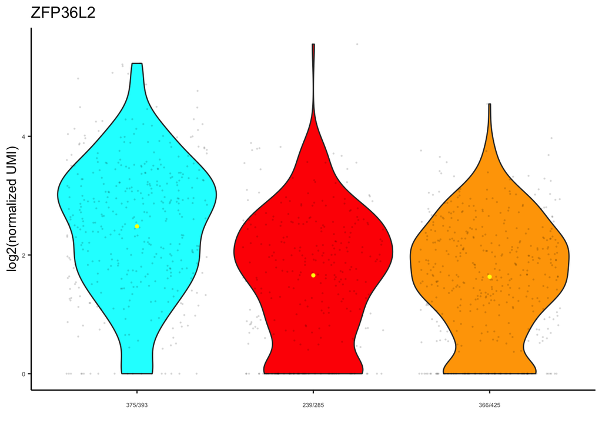

```r
plot_violin_for_genes_per_custom_group_of_cells(DBA_MKE,
                                                custom_group_of_cells = list(Ecyc.WT,Ecyc.RPS,Ecyc.RPL),
                                                gene_list = "ZFP36L2",
                                                take_log2 = T
)
```

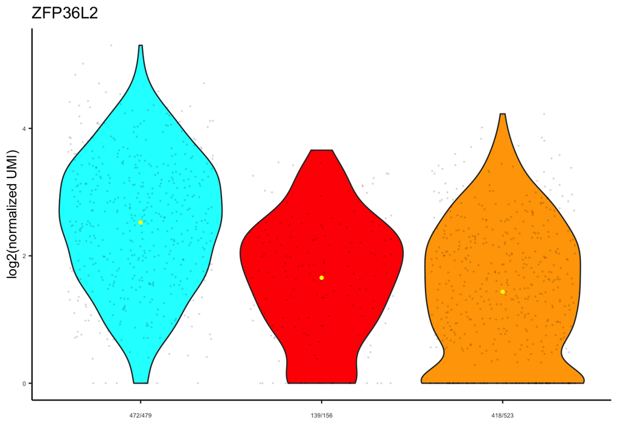

```r
plot_violin_for_genes_per_custom_group_of_cells(DBA_MKE,
                                                custom_group_of_cells = list(LEP.WT,LEP.RPS,LEP.RPL),
                                                gene_list = "ZFP36L2",
                                                take_log2 = T
)
```